# Optimal Treatment Analysis

## Outcome Variable

**Outcome Variable:** whz

## Predictor Variables

**Intervention Variable:** predfeed3

**Adjustment Set:**

- arm
- sex
- month
- brthmon
- W_mage
- meducyrs
- feducyrs
- hhwealth_quart
- hfoodsec
- W_mhtcm
- W_mwtkg
- W_mbmi
- vagbrth
- W_gagebrth
- W_birthwt
- W_birthlen
- W_nrooms
- W_nchldlt5
- W_parity
- impfloor
- impsan
- safeh20
- delta_W_mage
- delta_meducyrs
- delta_feducyrs
- delta_hhwealth_quart
- delta_hfoodsec
- delta_W_mhtcm
- delta_W_mwtkg
- delta_W_mbmi
- delta_vagbrth
- delta_W_gagebrth
- delta_W_birthwt
- delta_W_birthlen
- delta_W_nrooms
- delta_W_nchldlt5
- delta_W_parity
- delta_impfloor
- delta_impsan
- delta_safeh20

## Stratifying Variables

The analysis was stratified on these variable(s):

- agecat
- studyid
- country

## Data Summary

| agecat | studyid | country | predfeed3 | n_cell | n |
| --- | --- | --- | --- | --- | --- |
| Birth | ki0047075b-MAL-ED | BANGLADESH | 1 | 164 | 202 |
| Birth | ki0047075b-MAL-ED | BANGLADESH | 0 | 38 | 202 |
| Birth | ki0047075b-MAL-ED | BRAZIL | 1 | 23 | 55 |
| Birth | ki0047075b-MAL-ED | BRAZIL | 0 | 32 | 55 |
| Birth | ki0047075b-MAL-ED | INDIA | 1 | 27 | 39 |
| Birth | ki0047075b-MAL-ED | INDIA | 0 | 12 | 39 |
| Birth | ki0047075b-MAL-ED | NEPAL | 1 | 14 | 25 |
| Birth | ki0047075b-MAL-ED | NEPAL | 0 | 11 | 25 |
| Birth | ki0047075b-MAL-ED | PERU | 1 | 145 | 218 |
| Birth | ki0047075b-MAL-ED | PERU | 0 | 73 | 218 |
| Birth | ki0047075b-MAL-ED | SOUTH AFRICA | 1 | 33 | 99 |
| Birth | ki0047075b-MAL-ED | SOUTH AFRICA | 0 | 66 | 99 |
| Birth | ki0047075b-MAL-ED | TANZANIA, UNITED REPUBLIC OF | 1 | 24 | 95 |
| Birth | ki0047075b-MAL-ED | TANZANIA, UNITED REPUBLIC OF | 0 | 71 | 95 |
| Birth | ki1000109-EE | PAKISTAN | 1 | 22 | 22 |
| Birth | ki1000109-EE | PAKISTAN | 0 | 0 | 22 |
| Birth | ki1113344-GMS-Nepal | NEPAL | 1 | 352 | 422 |
| Birth | ki1113344-GMS-Nepal | NEPAL | 0 | 70 | 422 |
| Birth | kiGH5241-JiVitA-3 | BANGLADESH | 1 | 10997 | 12129 |
| Birth | kiGH5241-JiVitA-3 | BANGLADESH | 0 | 1132 | 12129 |
| Birth | kiGH5241-JiVitA-4 | BANGLADESH | 1 | 89 | 97 |
| Birth | kiGH5241-JiVitA-4 | BANGLADESH | 0 | 8 | 97 |
| 6 months | ki0047075b-MAL-ED | BANGLADESH | 1 | 191 | 233 |
| 6 months | ki0047075b-MAL-ED | BANGLADESH | 0 | 42 | 233 |
| 6 months | ki0047075b-MAL-ED | BRAZIL | 1 | 93 | 187 |
| 6 months | ki0047075b-MAL-ED | BRAZIL | 0 | 94 | 187 |
| 6 months | ki0047075b-MAL-ED | INDIA | 1 | 147 | 210 |
| 6 months | ki0047075b-MAL-ED | INDIA | 0 | 63 | 210 |
| 6 months | ki0047075b-MAL-ED | NEPAL | 1 | 113 | 227 |
| 6 months | ki0047075b-MAL-ED | NEPAL | 0 | 114 | 227 |
| 6 months | ki0047075b-MAL-ED | PERU | 1 | 176 | 270 |
| 6 months | ki0047075b-MAL-ED | PERU | 0 | 94 | 270 |
| 6 months | ki0047075b-MAL-ED | SOUTH AFRICA | 1 | 63 | 244 |
| 6 months | ki0047075b-MAL-ED | SOUTH AFRICA | 0 | 181 | 244 |
| 6 months | ki0047075b-MAL-ED | TANZANIA, UNITED REPUBLIC OF | 1 | 64 | 212 |
| 6 months | ki0047075b-MAL-ED | TANZANIA, UNITED REPUBLIC OF | 0 | 148 | 212 |
| 6 months | ki1000109-EE | PAKISTAN | 1 | 39 | 39 |
| 6 months | ki1000109-EE | PAKISTAN | 0 | 0 | 39 |
| 6 months | ki1113344-GMS-Nepal | NEPAL | 1 | 367 | 441 |
| 6 months | ki1113344-GMS-Nepal | NEPAL | 0 | 74 | 441 |
| 6 months | kiGH5241-JiVitA-3 | BANGLADESH | 1 | 8481 | 9289 |
| 6 months | kiGH5241-JiVitA-3 | BANGLADESH | 0 | 808 | 9289 |
| 6 months | kiGH5241-JiVitA-4 | BANGLADESH | 1 | 76 | 88 |
| 6 months | kiGH5241-JiVitA-4 | BANGLADESH | 0 | 12 | 88 |
| 24 months | ki0047075b-MAL-ED | BANGLADESH | 1 | 168 | 205 |
| 24 months | ki0047075b-MAL-ED | BANGLADESH | 0 | 37 | 205 |
| 24 months | ki0047075b-MAL-ED | BRAZIL | 1 | 79 | 152 |
| 24 months | ki0047075b-MAL-ED | BRAZIL | 0 | 73 | 152 |
| 24 months | ki0047075b-MAL-ED | INDIA | 1 | 139 | 202 |
| 24 months | ki0047075b-MAL-ED | INDIA | 0 | 63 | 202 |
| 24 months | ki0047075b-MAL-ED | NEPAL | 1 | 110 | 220 |
| 24 months | ki0047075b-MAL-ED | NEPAL | 0 | 110 | 220 |
| 24 months | ki0047075b-MAL-ED | PERU | 1 | 131 | 198 |
| 24 months | ki0047075b-MAL-ED | PERU | 0 | 67 | 198 |
| 24 months | ki0047075b-MAL-ED | SOUTH AFRICA | 1 | 60 | 228 |
| 24 months | ki0047075b-MAL-ED | SOUTH AFRICA | 0 | 168 | 228 |
| 24 months | ki0047075b-MAL-ED | TANZANIA, UNITED REPUBLIC OF | 1 | 54 | 184 |
| 24 months | ki0047075b-MAL-ED | TANZANIA, UNITED REPUBLIC OF | 0 | 130 | 184 |
| 24 months | ki1000109-EE | PAKISTAN | 1 | 20 | 20 |
| 24 months | ki1000109-EE | PAKISTAN | 0 | 0 | 20 |
| 24 months | ki1113344-GMS-Nepal | NEPAL | 1 | 322 | 384 |
| 24 months | ki1113344-GMS-Nepal | NEPAL | 0 | 62 | 384 |
| 24 months | kiGH5241-JiVitA-3 | BANGLADESH | 1 | 4381 | 4795 |
| 24 months | kiGH5241-JiVitA-3 | BANGLADESH | 0 | 414 | 4795 |
| 24 months | kiGH5241-JiVitA-4 | BANGLADESH | 1 | 135 | 150 |
| 24 months | kiGH5241-JiVitA-4 | BANGLADESH | 0 | 15 | 150 |

The following strata were considered:

- agecat: 24 months, studyid: ki0047075b-MAL-ED, country: BANGLADESH
- agecat: 24 months, studyid: ki0047075b-MAL-ED, country: BRAZIL
- agecat: 24 months, studyid: ki0047075b-MAL-ED, country: INDIA
- agecat: 24 months, studyid: ki0047075b-MAL-ED, country: NEPAL
- agecat: 24 months, studyid: ki0047075b-MAL-ED, country: PERU
- agecat: 24 months, studyid: ki0047075b-MAL-ED, country: SOUTH AFRICA
- agecat: 24 months, studyid: ki0047075b-MAL-ED, country: TANZANIA, UNITED REPUBLIC OF
- agecat: 24 months, studyid: ki1000109-EE, country: PAKISTAN
- agecat: 24 months, studyid: ki1113344-GMS-Nepal, country: NEPAL
- agecat: 24 months, studyid: kiGH5241-JiVitA-3, country: BANGLADESH
- agecat: 24 months, studyid: kiGH5241-JiVitA-4, country: BANGLADESH
- agecat: 6 months, studyid: ki0047075b-MAL-ED, country: BANGLADESH
- agecat: 6 months, studyid: ki0047075b-MAL-ED, country: BRAZIL
- agecat: 6 months, studyid: ki0047075b-MAL-ED, country: INDIA
- agecat: 6 months, studyid: ki0047075b-MAL-ED, country: NEPAL
- agecat: 6 months, studyid: ki0047075b-MAL-ED, country: PERU
- agecat: 6 months, studyid: ki0047075b-MAL-ED, country: SOUTH AFRICA
- agecat: 6 months, studyid: ki0047075b-MAL-ED, country: TANZANIA, UNITED REPUBLIC OF
- agecat: 6 months, studyid: ki1000109-EE, country: PAKISTAN
- agecat: 6 months, studyid: ki1113344-GMS-Nepal, country: NEPAL
- agecat: 6 months, studyid: kiGH5241-JiVitA-3, country: BANGLADESH
- agecat: 6 months, studyid: kiGH5241-JiVitA-4, country: BANGLADESH
- agecat: Birth, studyid: ki0047075b-MAL-ED, country: BANGLADESH
- agecat: Birth, studyid: ki0047075b-MAL-ED, country: BRAZIL
- agecat: Birth, studyid: ki0047075b-MAL-ED, country: INDIA
- agecat: Birth, studyid: ki0047075b-MAL-ED, country: NEPAL
- agecat: Birth, studyid: ki0047075b-MAL-ED, country: PERU
- agecat: Birth, studyid: ki0047075b-MAL-ED, country: SOUTH AFRICA
- agecat: Birth, studyid: ki0047075b-MAL-ED, country: TANZANIA, UNITED REPUBLIC OF
- agecat: Birth, studyid: ki1000109-EE, country: PAKISTAN
- agecat: Birth, studyid: ki1113344-GMS-Nepal, country: NEPAL
- agecat: Birth, studyid: kiGH5241-JiVitA-3, country: BANGLADESH
- agecat: Birth, studyid: kiGH5241-JiVitA-4, country: BANGLADESH

### Dropped Strata

Some strata were dropped due to rare outcomes:

- agecat: Birth, studyid: ki1000109-EE, country: PAKISTAN
- agecat: 6 months, studyid: ki1000109-EE, country: PAKISTAN
- agecat: 24 months, studyid: ki1000109-EE, country: PAKISTAN

## Methods Detail

We’re interested in the causal parameters $E[Y_a]$ for all values of $a \in \mathcal{A}$. These parameters represent the mean outcome if, possibly contrary to fact, we intervened to set all units to have $A=a$. Under the randomization and positivity assumptions, these are identified by the statistical parameters $\psi_a=E_W[E_{Y|A,W}(Y|A=a,W)]$. In addition, we’re interested in the mean of $Y$, $E[Y]$ under no intervention (the observed mean). We will estimate these parameters by using SuperLearner to fit the relevant likelihood factors – $E_{Y|A,W}(Y|A=a,W)$ and $p(A=a|W)$, and then updating our likelihood fit using a joint TMLE.

For unadjusted analyses ($W=\{\}$), initial likelihoods were estimated using Lrnr_glm to estimate the simple $E(Y|A)$ and Lrnr_mean to estimate $p(A)$. For adjusted analyses, a small library containing Lrnr_glmnet, Lrnr_xgboost, and Lrnr_mean was used.

Having estimated these parameters, we will then use the delta method to estimate relative risks and attributable risks relative to a prespecified baseline level of $A$.

# Results Detail

## Results Plots

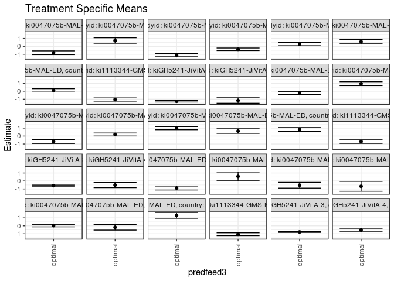

## Results Table

### Parameter: TSM

| agecat | studyid | country | intervention_level | baseline_level | estimate | ci_lower | ci_upper |
| --- | --- | --- | --- | --- | --- | --- | --- |
| Birth | ki0047075b-MAL-ED | BANGLADESH | optimal | observed | -0.8896464 | -1.1387282 | -0.6405645 |
| Birth | ki0047075b-MAL-ED | BRAZIL | optimal | observed | 0.5708694 | 0.0127757 | 1.1289630 |
| Birth | ki0047075b-MAL-ED | INDIA | optimal | observed | -0.5320342 | -0.8933434 | -0.1707250 |
| Birth | ki0047075b-MAL-ED | NEPAL | optimal | observed | -0.6735808 | -1.2945875 | -0.0525742 |
| Birth | ki0047075b-MAL-ED | PERU | optimal | observed | 0.0266671 | -0.1293010 | 0.1826353 |
| Birth | ki0047075b-MAL-ED | SOUTH AFRICA | optimal | observed | -0.1907781 | -0.5404325 | 0.1588762 |
| Birth | ki0047075b-MAL-ED | TANZANIA, UNITED REPUBLIC OF | optimal | observed | 1.3127082 | 0.9489822 | 1.6764341 |
| Birth | ki1113344-GMS-Nepal | NEPAL | optimal | observed | -1.0589486 | -1.2356124 | -0.8822847 |
| Birth | kiGH5241-JiVitA-3 | BANGLADESH | optimal | observed | -0.7704426 | -0.8307548 | -0.7101303 |
| Birth | kiGH5241-JiVitA-4 | BANGLADESH | optimal | observed | -0.5330738 | -0.7558970 | -0.3102505 |
| 6 months | ki0047075b-MAL-ED | BANGLADESH | optimal | observed | -0.2261693 | -0.4216093 | -0.0307292 |
| 6 months | ki0047075b-MAL-ED | BRAZIL | optimal | observed | 0.9441842 | 0.7001681 | 1.1882004 |
| 6 months | ki0047075b-MAL-ED | INDIA | optimal | observed | -0.6947647 | -0.9356077 | -0.4539216 |
| 6 months | ki0047075b-MAL-ED | NEPAL | optimal | observed | 0.1930656 | 0.0070659 | 0.3790653 |
| 6 months | ki0047075b-MAL-ED | PERU | optimal | observed | 0.9943181 | 0.7942155 | 1.1944208 |
| 6 months | ki0047075b-MAL-ED | SOUTH AFRICA | optimal | observed | 0.6299081 | 0.3364357 | 0.9233806 |
| 6 months | ki0047075b-MAL-ED | TANZANIA, UNITED REPUBLIC OF | optimal | observed | 0.8241563 | 0.5762164 | 1.0720963 |
| 6 months | ki1113344-GMS-Nepal | NEPAL | optimal | observed | -0.7008929 | -0.9243707 | -0.4774150 |
| 6 months | kiGH5241-JiVitA-3 | BANGLADESH | optimal | observed | -0.5879270 | -0.6596921 | -0.5161619 |
| 6 months | kiGH5241-JiVitA-4 | BANGLADESH | optimal | observed | -0.5178187 | -0.8455127 | -0.1901247 |
| 24 months | ki0047075b-MAL-ED | BANGLADESH | optimal | observed | -0.8057128 | -1.0418548 | -0.5695709 |
| 24 months | ki0047075b-MAL-ED | BRAZIL | optimal | observed | 0.7348696 | 0.3892358 | 1.0805034 |
| 24 months | ki0047075b-MAL-ED | INDIA | optimal | observed | -1.1102553 | -1.3092650 | -0.9112456 |
| 24 months | ki0047075b-MAL-ED | NEPAL | optimal | observed | -0.3689845 | -0.5322573 | -0.2057117 |
| 24 months | ki0047075b-MAL-ED | PERU | optimal | observed | 0.2827193 | 0.0792131 | 0.4862255 |
| 24 months | ki0047075b-MAL-ED | SOUTH AFRICA | optimal | observed | 0.5841265 | 0.3189305 | 0.8493225 |
| 24 months | ki0047075b-MAL-ED | TANZANIA, UNITED REPUBLIC OF | optimal | observed | 0.1008552 | -0.1084247 | 0.3101351 |
| 24 months | ki1113344-GMS-Nepal | NEPAL | optimal | observed | -1.0478227 | -1.2543614 | -0.8412840 |
| 24 months | kiGH5241-JiVitA-3 | BANGLADESH | optimal | observed | -1.2705274 | -1.3681977 | -1.1728570 |
| 24 months | kiGH5241-JiVitA-4 | BANGLADESH | optimal | observed | -1.1695497 | -1.5165417 | -0.8225578 |

### Parameter: E(Y)

| agecat | studyid | country | intervention_level | baseline_level | estimate | ci_lower | ci_upper |
| --- | --- | --- | --- | --- | --- | --- | --- |
| Birth | ki0047075b-MAL-ED | BANGLADESH | observed | observed | -0.9404455 | -1.0889530 | -0.7919381 |
| Birth | ki0047075b-MAL-ED | BRAZIL | observed | observed | 0.4316364 | 0.0969688 | 0.7663039 |
| Birth | ki0047075b-MAL-ED | INDIA | observed | observed | -0.9779487 | -1.2664810 | -0.6894164 |
| Birth | ki0047075b-MAL-ED | NEPAL | observed | observed | -0.7944000 | -1.1625222 | -0.4262778 |
| Birth | ki0047075b-MAL-ED | PERU | observed | observed | -0.0335321 | -0.1564905 | 0.0894263 |
| Birth | ki0047075b-MAL-ED | SOUTH AFRICA | observed | observed | -0.1588889 | -0.3845288 | 0.0667510 |
| Birth | ki0047075b-MAL-ED | TANZANIA, UNITED REPUBLIC OF | observed | observed | 0.7996842 | 0.5874808 | 1.0118876 |
| Birth | ki1113344-GMS-Nepal | NEPAL | observed | observed | -1.0991706 | -1.2073693 | -0.9909719 |
| Birth | kiGH5241-JiVitA-3 | BANGLADESH | observed | observed | -0.7822228 | -0.8038489 | -0.7605966 |
| Birth | kiGH5241-JiVitA-4 | BANGLADESH | observed | observed | -0.4347423 | -0.6441144 | -0.2253701 |
| 6 months | ki0047075b-MAL-ED | BANGLADESH | observed | observed | -0.1312375 | -0.2633777 | 0.0009027 |
| 6 months | ki0047075b-MAL-ED | BRAZIL | observed | observed | 0.9730392 | 0.7966084 | 1.1494700 |
| 6 months | ki0047075b-MAL-ED | INDIA | observed | observed | -0.7190952 | -0.8496984 | -0.5884921 |
| 6 months | ki0047075b-MAL-ED | NEPAL | observed | observed | 0.1047871 | -0.0305193 | 0.2400934 |
| 6 months | ki0047075b-MAL-ED | PERU | observed | observed | 1.0554753 | 0.9329598 | 1.1779909 |
| 6 months | ki0047075b-MAL-ED | SOUTH AFRICA | observed | observed | 0.5569945 | 0.4061636 | 0.7078255 |
| 6 months | ki0047075b-MAL-ED | TANZANIA, UNITED REPUBLIC OF | observed | observed | 0.5257626 | 0.3871543 | 0.6643709 |
| 6 months | ki1113344-GMS-Nepal | NEPAL | observed | observed | -0.6198791 | -0.7206518 | -0.5191063 |
| 6 months | kiGH5241-JiVitA-3 | BANGLADESH | observed | observed | -0.6040726 | -0.6286341 | -0.5795110 |
| 6 months | kiGH5241-JiVitA-4 | BANGLADESH | observed | observed | -0.4110227 | -0.6122701 | -0.2097753 |
| 24 months | ki0047075b-MAL-ED | BANGLADESH | observed | observed | -0.8086098 | -0.9307952 | -0.6864243 |
| 24 months | ki0047075b-MAL-ED | BRAZIL | observed | observed | 0.4943421 | 0.2716679 | 0.7170163 |
| 24 months | ki0047075b-MAL-ED | INDIA | observed | observed | -0.9524010 | -1.0710590 | -0.8337430 |
| 24 months | ki0047075b-MAL-ED | NEPAL | observed | observed | -0.3806364 | -0.4971717 | -0.2641010 |
| 24 months | ki0047075b-MAL-ED | PERU | observed | observed | 0.1199242 | 0.0008627 | 0.2389858 |
| 24 months | ki0047075b-MAL-ED | SOUTH AFRICA | observed | observed | 0.4181579 | 0.2964894 | 0.5398263 |
| 24 months | ki0047075b-MAL-ED | TANZANIA, UNITED REPUBLIC OF | observed | observed | 0.0485870 | -0.0868148 | 0.1839888 |
| 24 months | ki1113344-GMS-Nepal | NEPAL | observed | observed | -1.1396441 | -1.2416403 | -1.0376479 |
| 24 months | kiGH5241-JiVitA-3 | BANGLADESH | observed | observed | -1.3119979 | -1.3435475 | -1.2804484 |
| 24 months | kiGH5241-JiVitA-4 | BANGLADESH | observed | observed | -1.0096000 | -1.1619164 | -0.8572836 |

### Parameter: PAR

| agecat | studyid | country | intervention_level | baseline_level | estimate | ci_lower | ci_upper |
| --- | --- | --- | --- | --- | --- | --- | --- |
| Birth | ki0047075b-MAL-ED | BANGLADESH | optimal | observed | -0.0507992 | -0.2569991 | 0.1554008 |
| Birth | ki0047075b-MAL-ED | BRAZIL | optimal | observed | -0.1392330 | -0.5765853 | 0.2981193 |
| Birth | ki0047075b-MAL-ED | INDIA | optimal | observed | -0.4459146 | -0.7707020 | -0.1211271 |
| Birth | ki0047075b-MAL-ED | NEPAL | optimal | observed | -0.1208192 | -0.6841282 | 0.4424898 |
| Birth | ki0047075b-MAL-ED | PERU | optimal | observed | -0.0601993 | -0.1589827 | 0.0385842 |
| Birth | ki0047075b-MAL-ED | SOUTH AFRICA | optimal | observed | 0.0318893 | -0.1936172 | 0.2573958 |
| Birth | ki0047075b-MAL-ED | TANZANIA, UNITED REPUBLIC OF | optimal | observed | -0.5130239 | -0.8496029 | -0.1764450 |
| Birth | ki1113344-GMS-Nepal | NEPAL | optimal | observed | -0.0402220 | -0.1976377 | 0.1171936 |
| Birth | kiGH5241-JiVitA-3 | BANGLADESH | optimal | observed | -0.0117802 | -0.0682236 | 0.0446633 |
| Birth | kiGH5241-JiVitA-4 | BANGLADESH | optimal | observed | 0.0983315 | -0.0159814 | 0.2126444 |
| 6 months | ki0047075b-MAL-ED | BANGLADESH | optimal | observed | 0.0949318 | -0.0482795 | 0.2381431 |
| 6 months | ki0047075b-MAL-ED | BRAZIL | optimal | observed | 0.0288550 | -0.1474120 | 0.2051220 |
| 6 months | ki0047075b-MAL-ED | INDIA | optimal | observed | -0.0243306 | -0.2075785 | 0.1589174 |
| 6 months | ki0047075b-MAL-ED | NEPAL | optimal | observed | -0.0882785 | -0.2246325 | 0.0480754 |
| 6 months | ki0047075b-MAL-ED | PERU | optimal | observed | 0.0611572 | -0.0839847 | 0.2062991 |
| 6 months | ki0047075b-MAL-ED | SOUTH AFRICA | optimal | observed | -0.0729136 | -0.3398158 | 0.1939886 |
| 6 months | ki0047075b-MAL-ED | TANZANIA, UNITED REPUBLIC OF | optimal | observed | -0.2983938 | -0.5056482 | -0.0911393 |
| 6 months | ki1113344-GMS-Nepal | NEPAL | optimal | observed | 0.0810138 | -0.1241396 | 0.2861672 |
| 6 months | kiGH5241-JiVitA-3 | BANGLADESH | optimal | observed | -0.0161455 | -0.0835216 | 0.0512305 |
| 6 months | kiGH5241-JiVitA-4 | BANGLADESH | optimal | observed | 0.1067960 | -0.1727342 | 0.3863262 |
| 24 months | ki0047075b-MAL-ED | BANGLADESH | optimal | observed | -0.0028969 | -0.2049401 | 0.1991463 |
| 24 months | ki0047075b-MAL-ED | BRAZIL | optimal | observed | -0.2405275 | -0.4782205 | -0.0028344 |
| 24 months | ki0047075b-MAL-ED | INDIA | optimal | observed | 0.1578543 | 0.0095150 | 0.3061936 |
| 24 months | ki0047075b-MAL-ED | NEPAL | optimal | observed | -0.0116519 | -0.1250171 | 0.1017133 |
| 24 months | ki0047075b-MAL-ED | PERU | optimal | observed | -0.1627950 | -0.3130022 | -0.0125879 |
| 24 months | ki0047075b-MAL-ED | SOUTH AFRICA | optimal | observed | -0.1659686 | -0.4001980 | 0.0682608 |
| 24 months | ki0047075b-MAL-ED | TANZANIA, UNITED REPUBLIC OF | optimal | observed | -0.0522683 | -0.2439656 | 0.1394290 |
| 24 months | ki1113344-GMS-Nepal | NEPAL | optimal | observed | -0.0918214 | -0.2771557 | 0.0935130 |
| 24 months | kiGH5241-JiVitA-3 | BANGLADESH | optimal | observed | -0.0414705 | -0.1314087 | 0.0484676 |
| 24 months | kiGH5241-JiVitA-4 | BANGLADESH | optimal | observed | 0.1599497 | -0.1822707 | 0.5021701 |